# xwMOOC 데이터 과학

추천 시스템(Recommendation System) - 내용기반 필터링 추천(Content-based Filtering Recommendation)

xwMOOC

2017-08-18

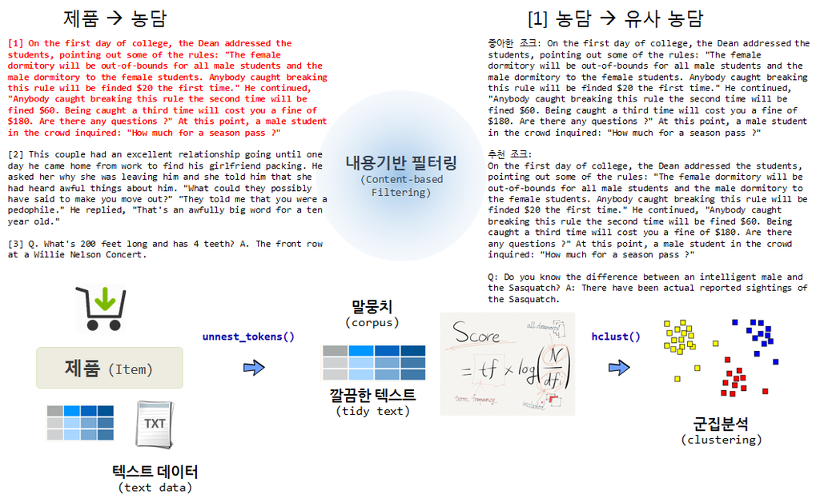

## 1. 내용기반 필터링(Content-based Filtering)

제품에는 제품의 특성을 기술하는 다양한 정보가 포함되어 있는데, 대표적으로 영화 줄거리가 영화에 대부분 포함되어 있다. 그 외에도 영화 쟝르, 주연배우, 제작사, 제작비 등이 포함된다. 이러한 특성을 바탕으로 유사한 제품을 묶어 추천하는 것이 유사할 수 있다.

이번에는 제품을 농담(Joke)으로 상정하고 특정 농담과 유사한 농담을 추천하는 시스템을 개발해 보자.

## 2. 농담 추천 시스템 {#joke-recommendation} [^1]

### 2.1. 농담 데이터

`recommenderlab` 팩키지에 추천시스템 개발에 사용될 수 있는 좋은 데이터가 다수 포함되어 있다. `Jester5k` 데이터셋은 1999년부터 2003년 사이 수집된 Jester 온라인 농담 추천시스템에서 5,000 유저가 평점을 내린 데이터가 포함되어 있다.

```r
# 0. 환경설정 ------------------------------
# library(recommenderlab)
# library(tidyverse)
# library(stringr)
# library(tidytext)
# library(SnowballC)
# library(tm)
# library(dbscan)
# library(proxy)
# library(extrafont)
# loadfonts()
# par(family = "NanumGothic")

# 1. 농담 데이터 ------------------------------

data("Jester5k")

JesterJokes_df <- as.data.frame(JesterJokes)
DT::datatable(JesterJokes_df)
```

|  | JesterJokes |
| --- | --- |
| j1 | A man visits the doctor. The doctor says "I have bad news for you.You have cancer and Alzheimer's disease". The man replies "Well,thank God I don't have cancer!" |
| j2 | This couple had an excellent relationship going until one day he came home from work to find his girlfriend packing. He asked her why she was leaving him and she told him that she had heard awful thin… |
| j3 | Q. What's 200 feet long and has 4 teeth? A. The front row at a Willie Nelson Concert. |
| j4 | Q. What's the difference between a man and a toilet? A. A toilet doesn't follow you around after you use it. |
| j5 | Q. What's O. J. Simpson's Internet address? A. Slash, slash, backslash, slash, slash, escape. |
| j6 | Bill &amp; Hillary are on a trip back to Arkansas. They're almost out of gas, so Bill pulls into a service station on the outskirts of town. The attendant runs out of the station to serve them when Hi… |
| j7 | How many feminists does it take to screw in a light bulb? That's not funny. |
| j8 | Q. Did you hear about the dyslexic devil worshiper? A. He sold his soul to Santa. |
| j9 | A country guy goes into a city bar that has a dress code, and the maitre d' demands he wear a tie. Discouraged, the guy goes to his car to sulk when inspiration strikes: He's got jumper cables in the … |
| j10 | Two cannibals are eating a clown, one turns to other and says: "Does this taste funny to you? |

[output cut: 90 more lines]

### 2.2. 텍스트 데이터 전처리

전통적으로 `tm` 팩키지를 활용하여 텍스트 데이터를 말뭉치(Corpus)로 변환시키고 이를 문서단어행렬(Document Term Matrix)로 변환하고, 다시 tf-idf 로 변환시켜 텍스트를 분석할 수 있는 적절한 형태로 가공시킨다. 이를 `clean_joke` 함수로 구성하면 다음과 같다.

```r
# 2. 농담 데이터 전처리------------------------
# 농담 텍스트 --> 문서단어행렬 --> tf-idf
clean_joke <- function(jokes) {
    source <- VectorSource(jokes)
    corp <- VCorpus(source)

    corp <- tm_map(corp, content_transformer(tolower))
    corp <- tm_map(corp, removeWords, stopwords("english"))
    corp <- tm_map(corp, removeNumbers)
    corp <- tm_map(corp, removePunctuation)
    corp <- tm_map(corp, stemDocument)
    corp <- tm_map(corp, stripWhitespace)

    dtm <- DocumentTermMatrix(corp)
    tfidf <- weightTfIdf(dtm, normalize = TRUE)
    return(tfidf)
}

joke_tfidf <- clean_joke(JesterJokes)

inspect(joke_tfidf[1:10, 1:8])
```

```
<<DocumentTermMatrix (documents: 10, terms: 8)>>
Non-/sparse entries: 1/79
Sparsity           : 99%
Maximal term length: 9
Weighting          : term frequency - inverse document frequency (normalized) (tf-idf)
Sample             :
    Terms
Docs abort accompani account acquit actual add   address adopt
  1      0         0       0      0      0   0 0.0000000     0
  10     0         0       0      0      0   0 0.0000000     0
  2      0         0       0      0      0   0 0.0000000     0
  3      0         0       0      0      0   0 0.0000000     0
  4      0         0       0      0      0   0 0.0000000     0
  5      0         0       0      0      0   0 0.6270951     0
  6      0         0       0      0      0   0 0.0000000     0
  7      0         0       0      0      0   0 0.0000000     0
  8      0         0       0      0      0   0 0.0000000     0
  9      0         0       0      0      0   0 0.0000000     0
```

## 3. 군집분석을 추천 시스템 핵심 엔진으로 구축

`tf-idf` 형태 텍스트 데이터로 가공시키면 군집분석을 활용하여 추천시스템을 개발하는 과정은 다양한 알고리즘을 적용하여 적절한 추천시스템을 개발하는 단계로 넘어가게 된다.

### 3.1. 계층 군집분석

코사인을 거리로 정의하고 이를 바탕으로 계층 군집분석을 시작한다. 그리고, 군집화하는 데이터가 크지 않아 시각화가 가능하다. 이를 바탕으로 `recommend_jokes` 함수를 만들어 추천시스템을 개발한다.

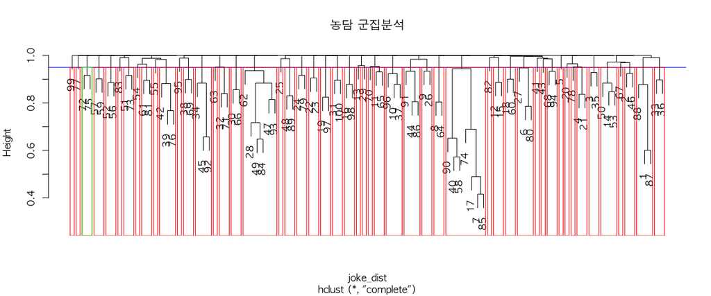

```r
# 3. 군집분석------------------------
## 3.1. 계층 군집분석 ---------------
joke_dist <- dist(as.matrix(joke_tfidf), method = "cosine")
joke_hc <- hclust(joke_dist)

## 3.2. 계층 군집분석 시각화 --------
# 군집결정
joke_cluster <- cutree(joke_hc, h = 0.95)

# 결정된 군집 시각화
plot(joke_hc, main="농담 군집분석")
abline(h=0.95, col="blue")
rect.hclust(joke_hc, h = 0.95, border = "red")
# 관심있는 첫번째 군집
rect.hclust(joke_hc, h = 0.95,  which=3, border = "green")
```

```r
## 3.3. 계층 군집분석 추천 --------
recommend_jokes <- function(joke_number) {
    cat("좋아한 조크: ", JesterJokes[joke_number], "\n\n")
    cat("추천 조크: ", JesterJokes[joke_cluster==joke_cluster[joke_number]], sep = "\n\n")
}

recommend_jokes(72)
```

```
좋아한 조크:  On the first day of college, the Dean addressed the students, pointing out some of the rules: "The female dormitory will be out-of-bounds for all male students and the male dormitory to the female students. Anybody caught breaking this rule will be finded $20 the first time." He continued, …

추천 조크:

On the first day of college, the Dean addressed the students, pointing out some of the rules: "The female dormitory will be out-of-bounds for all male students and the male dormitory to the female students. Anybody caught breaking this rule will be finded $20 the first time." He continued, "Anybody …

Q: Do you know the difference between an intelligent male and the Sasquatch? A: There have been actual reported sightings of the Sasquatch.
```

### 3.2. kNN 군집분석

동일한 방법으로 인접한 농담을 5개 찾아 추천하는 알고리즘을 구현하면 다음과 같다.

```r
## 3.2. k-근접이웃 추천 ---------------

joke_nn <- kNN(joke_dist, 5)

recommend_knn_jokes <- function(joke_number) {
    cat("좋아한 조크: ", JesterJokes[joke_number], "\n\n")
    cat("추천 조크: ", JesterJokes[joke_nn$id[joke_number,]], sep = "\n\n")
}

recommend_knn_jokes(72)
```

```
좋아한 조크:  On the first day of college, the Dean addressed the students, pointing out some of the rules: "The female dormitory will be out-of-bounds for all male students and the male dormitory to the female students. Anybody caught breaking this rule will be finded $20 the first time." He continued, …

추천 조크:

Q: Do you know the difference between an intelligent male and the Sasquatch? A: There have been actual reported sightings of the Sasquatch.

How many men does it take to screw in a light bulb? One...men will screw anything.

During a recent publicity outing, Hillary sneaked off to visit a fortune teller of some local repute. In a dark and hazy room, peering into a crystal ball, the mystic delivered grave news. "There's no easy way to say this, so I'll just be blunt: Prepare yourself to be a widow. Your husband will die …

Three engineering students were gathered together discussing the possible designers of the human body. One said, "It was a mechanical engineer. Just look at all the joints." Another said, "No, it was an electrical engineer. The nervous systems many thousands of electrical connections." The last said…

The graduate with a Science degree asks, "Why does it work?" The graduate with an Engineering degree asks, "How does it work?" The graduate with an Accounting degree Asks, "How much will it cost?" The graduate with a Liberal Arts degree asks, "Do you want fries with that?"
```

[^1]: [Recommender Systems: Simple Content-based Recommender Using Text Mining](http://michael.hahsler.net/other_courses/ICMA_Recommendation_Tools/code/content-based.html)